# 3dasm_Lecture11 slides

[figure not shown]

## Data-driven Design and Analyses of Structures and Materials (3dasm)

## Lecture 11

### Miguel A. Bessa | M.A.Bessa@tudelft.nl | Associate Professor

## **OPTION 1**. Run this notebook **locally in your computer**:

1. Confirm that you have the 3dasm conda environment (see Lecture 1).
2. Go to the 3dasm_course folder in your computer and pull the last updates of the [repository](https://github.com/bessagroup/3dasm_course):

   ```
   git pull
   ```

3. Open command window and load jupyter notebook (it will open in your internet browser):

   ```
   conda activate 3dasm
   jupyter notebook
   ```

4. Open notebook of this Lecture.

## **OPTION 2**. Use **Google's Colab** (no installation required, but times out if idle):

1. go to https://colab.research.google.com
2. login
3. File > Open notebook
4. click on Github (no need to login or authorize anything)
5. paste the git link: https://github.com/bessagroup/3dasm_course
6. click search and then click on the notebook for this Lecture.

## Outline for today

- Continuation of tutorial on supervised learning (again, no theory today!)
  - Multidimensional regression with Gaussian Processes and Artificial Neural Networks
- Classification with supervised learning: quick tutorial using Decision Trees and Support Vector Machines

**Reading material**: This notebook + (GPs in Section 17.3 of book; ANNs in Chapter 13)

## Today's lecture is also going to be more practical

Similarly to the previous lecture, we will focus on the practical aspects **without deriving the models yet**.

- Regression via supervised learning in multiple dimensions:
  - Today we will just focus only on **Gaussian Processes** using [scikit-learn](https://scikit-learn.org)

As we will see today, using ML models for multidimensional regression is very similar to the one-dimensional case we covered in the previous lectures.

## Creating a noiseless multidimensional dataset

Before we start, we need to consider a particular dataset for which we want to do regression.

As before, instead of downloading a particular dataset, let's create our own.

- There is a nice website listing many different benchmark functions used in optimization: https://www.sfu.ca/~ssurjano/optimization.html

We will learn some of them using Gaussian Processes...

```python
# Uncomment line below if you want to enable live rotation of the surface plots.
#%matplotlib notebook
#
from matplotlib import cm # to change colors of surface plots
#
# Let's define some functions that are often used to benchmark
# algorithms (especially in optimization)
def schwefel( x ):
    function_name = 'Schwefel' # to output name of function
    x = np.asarray_chkfinite(x)  # ValueError if any NaN or Inf
    if x.ndim == 1:
        x = np.reshape(x,(-1,2)) # reshape into 2d array
    #
    n_points, n_features = np.shape(x)
    y = np.empty((n_points,1))
    #
    for ii in range(n_points):
        y[ii] = 418.9829*n_features - sum( x[ii,:] * np.sin( np.sqrt( abs( x[ii,:] ))))
    return (np.atleast_1d(y), function_name)
#
# The next cell (hidden in presentation) includes a few more functions (so that you can play with this notebook).
```

Consider equally spaced sampling points to evaluate the function, as we did before for the 1D case.

```python
# Uniform grid of points for two-dimensional input
n_points_per_dimension = 50
x1 = np.linspace(-10.0, 10.0, n_points_per_dimension)
x2 = np.linspace(-10.0, 10.0, n_points_per_dimension)
# x3 = np.linspace(-10.0, 10.0, n_points_per_dimension) # if the input was 3D

X1_grid, X2_grid = np.meshgrid(x1, x2) # creates a grid of points that is necessary to plot surfaces
#X1_grid, X2_grid, X3_grid = np.meshgrid(x1, x2, x3) # e.g. for 3D input

print("Note that the X1_grid (and X2_grid) are 2D arrays with the following size:\n", np.shape(X1_grid))

# Input points reshaped for Pandas dataframe
Data_X = np.array([X1_grid, X2_grid]).reshape(2, -1).T
#Data_X = np.array([X1_grid, X2_grid, X3_grid]).reshape(3, -1).T
```

```
Note that the X1_grid (and X2_grid) are 2D arrays with the following size:
 (50, 50)
```

Now evaluate the function of interest (e.g. Schwefel function) at these input points.

```python
# Output data created from one of the benchmark functions:
# levy, ackley, rosenbrock, schwefel, griewank, rastrigin
Data_y, function_name = schwefel(Data_X) # calculate the output vector Data_y (1D output) from input data (2D input)

print("The output of the function is a vector with size:\n", np.shape(Data_y))

# Reshape output data for use in Surface plot:
Y_grid = np.reshape(Data_y,np.shape(X1_grid))

print("So, we reshape the output vector into a 2D array needed to plot surfaces:\n", np.shape(Y_grid))

# Set the color scheme used in every plot:
set_cm = cm.cool # viridis, inferno, copper, PuBu, cool, coolwarm, hsv
```

```
The output of the function is a vector with size:
 (2500, 1)
So, we reshape the output vector into a 2D array needed to plot surfaces:
 (50, 50)
```

Let's plot the function in a few different ways:

- Left subplot: 3D surface of the function
- Right subplot: a wireframe of the surface (no colors)

```python
fig1 = plt.figure(figsize=plt.figaspect(0.5)); ax1 = [];
# Subplot 1 (left) of Figure 1
ax1.append(fig1.add_subplot(1, 2, 1, projection='3d')) # just a way to use the same variable for all axes of fig1.
# Surface plot:
surf = ax1[0].plot_surface(X1_grid, X2_grid, Y_grid, cmap=set_cm, alpha=0.8, linewidth=0, antialiased=False)
ax1[0].set_xlabel('$x_1$', fontsize=15)
ax1[0].set_ylabel('$x_2$', fontsize=15)
ax1[0].set_zlabel('$f(x_1,x_2)$', fontsize=15)
ax1[0].set_title("%s function" % function_name, fontsize=15)

# Subplot 2 (right) of Figure 1
ax1.append(fig1.add_subplot(1, 2, 2, projection='3d'))
# Plot a 3D wireframe (no colors)
ax1[1].plot_wireframe(X1_grid, X2_grid, Y_grid, rstride=5, cstride=5)
ax1[1].set_xlabel('$x_1$', fontsize=15)
ax1[1].set_ylabel('$x_2$', fontsize=15)
ax1[1].set_zlabel('$f(x_1,x_2)$', fontsize=15)
ax1[1].set_title("%s function" % function_name, fontsize=15)
#plt.tight_layout() # if we want to enlarge the figures, but sometimes this leads to label occlusion.
fig1.set_size_inches(15, 6)
plt.close(fig1)
```

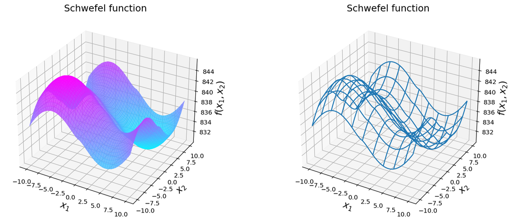

```python
fig1
```

In the next figure, we show a contour plot of the same function.

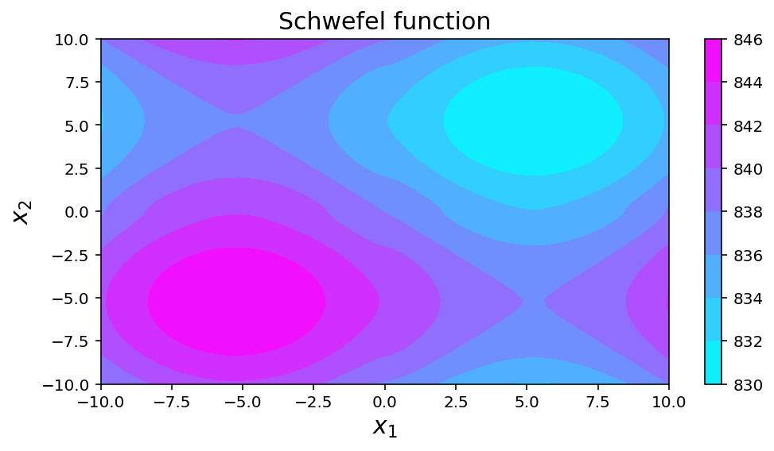

```python
fig2, ax2 = plt.subplots()
cset = ax2.contourf(X1_grid, X2_grid, Y_grid, cmap=set_cm)
ax2.set_xlabel('$x_1$', fontsize=15)
ax2.set_ylabel('$x_2$', fontsize=15)
ax2.set_title("%s function" % function_name, fontsize=15)
fig2.colorbar(cset, ax=ax2)
```

### Exercise 1

Go to this cell and choose a different function to be learned. Run the notebook until here to see how the function looks like.

#### Note on the Pandas DataFrame included in the "docs" folder

So, let's load this DataFrame and use it for training a Gaussian Process.

```python
import pandas as pd
df = pd.read_pickle("docs/data_noiseless_schwefel_2D_regression.pkl") # read pandas DataFrame
function_name = 'Schwefel' # The dataframe was created using the Schwefel function

print("Show the DataFrame in the docs folder:\n", df)
```

```
Show the DataFrame in the docs folder:
              x1    x2          y1
0    -10.000000 -10.0  837.552129
1     -9.591837 -10.0  838.185887
2     -9.183673 -10.0  838.777493
3     -8.775510 -10.0  839.323512
4     -8.367347 -10.0  839.820614
...         ...   ...         ...
2495   8.367347  10.0  836.110986
2496   8.775510  10.0  836.608088
2497   9.183673  10.0  837.154107
2498   9.591837  10.0  837.745713
2499  10.000000  10.0  838.379471

[2500 rows x 3 columns]
```

Although we introduced pandas in Lecture 2, you should keep exploring how it works...

For example, there are a few different ways to access the data of a DataFrame.

The notes below (not shown in the presentation), show you 3 different ways:

1. Direct way to select columns & rows by how they were labeled originaly
1. DataFrame.loc to select columns & rows by Name
1. DataFrame.iloc to select columns & rows by Index Positions (integer numbers)

```python
# Separate the features and targets into two different variables:
X_data = df.loc[:,['x1','x2']].values # note that we ask for all the values, not a subset of the DataFrame
y_data = df.loc[:,'y1'].values

# Recreate the grid of points that is necessary to plot surfaces (by reshaping)
X1_grid = np.reshape(X_data[:,0],( round( np.sqrt(len(X_data)) ), round( np.sqrt(len(X_data)) ) ))
X2_grid = np.reshape(X_data[:,1],( round( np.sqrt(len(X_data)) ), round( np.sqrt(len(X_data)) ) ))
Y_grid = np.reshape(y_data,( round( np.sqrt(len(X_data)) ), round( np.sqrt(len(X_data)) ) ))

print("Features loaded from the saved DataFrame:\n", X_data)
print("\nTarget loaded from the saved DataFrame:\n", y_data)
```

```
Features loaded from the saved DataFrame:
 [[-10.         -10.        ]
 [ -9.59183673 -10.        ]
 [ -9.18367347 -10.        ]
 ...
 [  9.18367347  10.        ]
 [  9.59183673  10.        ]
 [ 10.          10.        ]]

Target loaded from the saved DataFrame:
 [837.55212937 838.18588668 838.77749275 ... 837.15410725 837.74571332
 838.37947063]
```

## Multidimensional regression with Gaussian Processes

Let's create a Gaussian Process Regression model for the multidimensional data we loaded from that Pandas dataframe.

As usual, we split the dataset into training and testing sets.

- For now, we split the data with the following ratio: 2% for training set, and 98% for testing set

Note: the commonly used ratio is 75% for training and 25% for testing, but we will use Gaussian Processes and they can learn from very little data.

```python
# Train/test split like we did before!
from sklearn.model_selection import train_test_split

testset_ratio = 0.98 # ratio of test set points from the dataset

X_train, X_test, y_train, y_test = train_test_split(X_data, y_data,
                                                    test_size=testset_ratio,random_state=seed)
#
```

Now we can train the GP model on the training data and test it on the testing data, just like we did in the previous lectures.

```python
from sklearn.gaussian_process import GaussianProcessRegressor
from sklearn.gaussian_process.kernels import RBF, Matern, ExpSineSquared, ConstantKernel

# Define the kernel function
kernel = ConstantKernel(1.0, (1e-4, 1e4)) * RBF(10, (1e-2, 1e2)) # This is the standard RBF kernel
#kernel = 1.0 * RBF(10, (1e-2, 1e2)) # Same kernel as above
                                    #(scikit-learn assumes constant
                                    # variance if you just write RBF
                                    # without the constant kernel or
                                    # without multiplying by 1.0)

# Other examples of kernels:
#kernel = ExpSineSquared(length_scale=3.0, periodicity=3.14,
#                       length_scale_bounds=(0.1, 10.0),
#                       periodicity_bounds=(0.1, 10)) * RBF(3.0, (1e-2, 1e2))
#kernel = Matern(length_scale=1.0, length_scale_bounds=(1e-2, 1e2),nu=1.5)

gp_model = GaussianProcessRegressor(kernel=kernel, alpha=1e-3, n_restarts_optimizer=20) # using a small alpha

# Fit to data using Maximum Likelihood Estimation of the parameters
gp_model.fit(X_train, y_train) # here I am not scaling the target variable; only the features.

# Make the prediction on the entire dataset (for plotting), both for mean and standard deviation
y_data_GPpred, sigma_data_GPpred = gp_model.predict(X_data, return_std=True)

# Predict for test set (for error metric)
y_test_GPpred, sigma_test_GPpred = gp_model.predict(X_test, return_std=True)
```

```
/home/mabessa/miniconda3/envs/3dasm/lib/python3.9/site-packages/sklearn/gaussian_process/kernels.py:430: ConvergenceWarning: The optimal value found for dimension 0 of parameter k1__constant_value is close to the specified upper bound 10000.0. Increasing the bound and calling fit again may find a be…
  warnings.warn(
```

**IMPORTANT**: You probably got a warning message...

This is not just a minor "detail". It has important implications!

- This is a direct consequence of us not **pre-processing** the data adequately.

Before learning how to pre-process the data, let's visualize our GPR model and compare it to the ground truth function.

```python
fig3_WRONG = plt.figure(figsize=plt.figaspect(0.5)); ax3_WRONG = []
# Subplot 1 (left): ground truth
ax3_WRONG.append(fig3_WRONG.add_subplot(1, 2, 1, projection='3d'))
surf = ax3_WRONG[0].plot_surface(X1_grid, X2_grid, Y_grid,
                                 cmap=set_cm, alpha=0.8, linewidth=0, antialiased=False)
ax3_WRONG[0].set_xlabel('$x_1$', fontsize=15)
ax3_WRONG[0].set_ylabel('$x_2$', fontsize=15)
ax3_WRONG[0].set_zlabel('$f(x_1,x_2)$', fontsize=15)
ax3_WRONG[0].set_title("Ground truth of %s function" % function_name, fontsize=15)

# Subplot 2 (right): GPR approximation
ax3_WRONG.append(fig3_WRONG.add_subplot(1, 2, 2, projection='3d'))
Y_grid_data_GPpred = np.reshape(y_data_GPpred,np.shape(X1_grid)) # convert targets into grid format for plotting
surf = ax3_WRONG[1].plot_surface(X1_grid, X2_grid, Y_grid_data_GPpred,
                                 cmap=set_cm, alpha=0.8, linewidth=0, antialiased=False)
ax3_WRONG[1].set_xlabel('$x_1$', fontsize=15)
ax3_WRONG[1].set_ylabel('$x_2$', fontsize=15)
ax3_WRONG[1].set_zlabel('$f(x_1,x_2)$', fontsize=15)
ax3_WRONG[1].set_title("GPR mean for %s function" % function_name, fontsize=15)
ax3_WRONG[1].scatter(X_train[:,0], X_train[:,1], y_train, marker='o', color='red', label="training points")
ax3_WRONG[1].legend(loc='upper center')
#plt.tight_layout()
fig3_WRONG.set_size_inches(15, 6)
plt.close(fig3_WRONG) # close figure to open it in next cell.
```

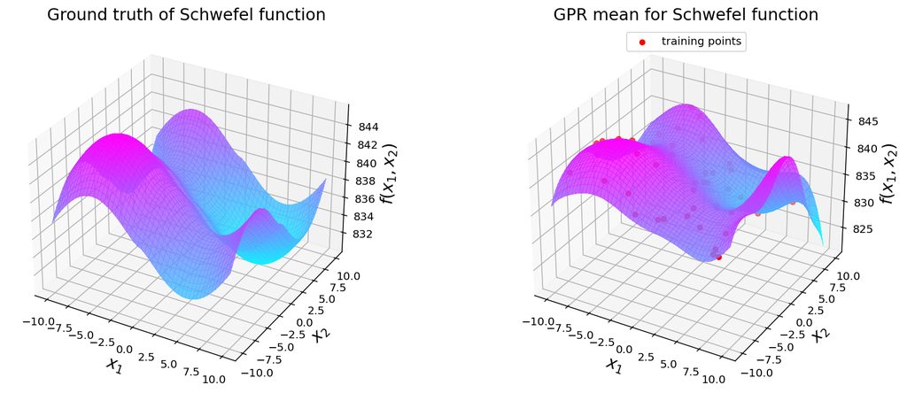

```python
fig3_WRONG # show figure illustrating the issues of not scaling the data appropriately!
```

This does not look great, especially at the boundary!

```python
fig4_WRONG = plt.figure(figsize=plt.figaspect(0.5)); ax4_WRONG = []
# Create Contour plot:
ax4_WRONG.append(fig4_WRONG.add_subplot(1, 3, 1))
cset = ax4_WRONG[0].contourf(X1_grid, X2_grid, Y_grid, cmap=set_cm)
ax4_WRONG[0].set_xlabel('$x_1$', fontsize=15)
ax4_WRONG[0].set_ylabel('$x_2$', fontsize=15)
ax4_WRONG[0].set_title("Ground truth of %s function" % function_name, fontsize=15)
fig4_WRONG.colorbar(cset, ax=ax4_WRONG[0])

# Create Contour plot:
ax4_WRONG.append(fig4_WRONG.add_subplot(1, 3, 2))
cset = ax4_WRONG[1].contourf(X1_grid, X2_grid, Y_grid_data_GPpred, cmap=set_cm)
ax4_WRONG[1].set_xlabel('$x_1$', fontsize=15)
ax4_WRONG[1].set_ylabel('$x_2$', fontsize=15)
ax4_WRONG[1].set_title("GPR mean for %s function" % function_name, fontsize=15)
fig4_WRONG.colorbar(cset, ax=ax4_WRONG[1])

# Create Contour plot:
ax4_WRONG.append(fig4_WRONG.add_subplot(1, 3, 3))

SIGMA_grid_data_GPpred = np.reshape(sigma_data_GPpred,np.shape(X1_grid))

cset = ax4_WRONG[2].contourf(X1_grid, X2_grid, SIGMA_grid_data_GPpred, cmap=set_cm)
ax4_WRONG[2].set_xlabel('$x_1$', fontsize=15)
ax4_WRONG[2].set_ylabel('$x_2$', fontsize=15)
ax4_WRONG[2].set_title("GPR STDV for %s function" % function_name, fontsize=15)
fig4_WRONG.colorbar(cset, ax=ax4_WRONG[2])

#plt.tight_layout()
fig4_WRONG.set_size_inches(15, 6)
plt.close(fig4_WRONG) # close figure to open it in next cell.
```

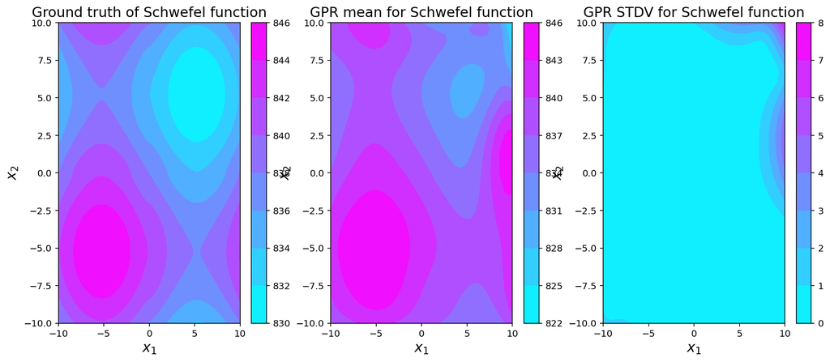

```python
fig4_WRONG # plot the same figure but using countour plots
```

Now we see clearly that the uncertainty is significant at the boundary!

This happened because the output values are large and we did not **pre-process** the dataset appropriately!

- It is good practice to **scale the dataset**.

Scikit-learn has implemented different [preprocessing](https://scikit-learn.org/stable/modules/preprocessing.html) strategies. **Check the documentation**.

The most common strategy is to standardize the dataset using the StandardScaler:

- StandardScaler: each feature is transformed to have zero-mean and unit standard deviation. In other words, the data becomes normally distributed (it is transformed). **Standardization of datasets is a common requirement for many machine learning models**.

```python
from sklearn.preprocessing import StandardScaler
# Scaling inputs with a Standard Scaler:
scaler_x = StandardScaler()
scaler_x.fit(X_train) # fit the scaler to the input data
#
X_train_scaled=scaler_x.transform(X_train) # scale the input training data
X_test_scaled=scaler_x.transform(X_test)  # scale the input testing data
X_data_scaled=scaler_x.transform(X_data) # scale the input data (the whole dataset)

idx = 0 # Choose the point you want to check the value (we could also plot the entire dataset.)
print("X_data[%i] is =" % idx, X_data[idx])
print("X_data_scaled[%i] is =" % idx, X_data_scaled[idx])
```

```
X_data[0] is = [-10. -10.]
X_data_scaled[0] is = [-1.79658824 -1.50411611]
```

```python
# Now scaling outputs also using StandardScaler:
y_train = y_train.reshape(-1, 1) # recall that we need to convert the 1D array vector into a 2D array vector
y_test = y_test.reshape(-1, 1)   # recall that we need to convert the 1D array vector into a 2D array vector
y_data = y_data.reshape(-1, 1)   # recall that we need to convert the 1D array vector into a 2D array vector
#
scaler_y = StandardScaler()
scaler_y.fit(y_train) # fit the scaler to the output data
#
y_train_scaled=scaler_y.transform(y_train) # scale the output training data
y_test_scaled=scaler_y.transform(y_test)  # scale the output testing data
y_data_scaled=scaler_y.transform(y_data) # scale the output data (the whole dataset)

idx = 0 # Choose the point you want to check the value (we could also plot the entire dataset.)
print("y_data[%i] is =" % idx, y_data[idx])
print("y_data_scaled[%i] is =" % idx, y_data_scaled[idx])
```

```
y_data[0] is = [837.55212937]
y_data_scaled[0] is = [-0.10898576]
```

```python
# Create the GP model again (same kernel, same parameters and same optimization process!)
kernel = ConstantKernel(1.0, (1e-4, 1e4)) * RBF(10, (1e-2, 1e2)) # This is the standard RBF kernel
gp_model = GaussianProcessRegressor(kernel=kernel, alpha=1e-3, n_restarts_optimizer=20) # using a small alpha

# The ONLY difference is that we will train the model on SCALED inputs and outputs
gp_model.fit(X_train_scaled, y_train_scaled) # here I am not scaling the target variable; only the features.

# Make the prediction on the entire dataset (for plotting), both for mean and standard deviation
y_data_GPpred_scaled, sigma_data_GPpred_scaled = gp_model.predict(X_data_scaled, return_std=True)
# IMPORTANT: we need to scale the predictions for the mean of the output back to the original scale!
y_data_GPpred = scaler_y.inverse_transform(y_data_GPpred_scaled) # mean
# IMPORTANT: we need to do the same for the standard deviation of the output, but in this case we have to subtract
#            by the mean of the training data because the standard deviation is not transformed by the
#            StandardScaler in the same way as the mean! In the Homework you will derive this...
sigma_data_GPpred = scaler_y.inverse_transform(sigma_data_GPpred_scaled.reshape(-1, 1)) - np.mean(y_train)
my_sigma_data_GPpred = sigma_data_GPpred_scaled.reshape(-1, 1)*np.std(y_train)

# Predict for test set (for error metric)
y_test_GPpred_scaled, sigma_test_GPpred_scaled = gp_model.predict(X_test_scaled, return_std=True)
# Scale mean and std back, as above.
y_test_GPpred = scaler_y.inverse_transform(y_test_GPpred_scaled)
sigma_test_GPpred = scaler_y.inverse_transform(sigma_test_GPpred_scaled.reshape(-1, 1)) - np.mean(y_train)
```

```python
fig3 = plt.figure(figsize=plt.figaspect(0.5)); ax3 = []
# Subplot 1 (left): ground truth
ax3.append(fig3.add_subplot(1, 2, 1, projection='3d'))
surf = ax3[0].plot_surface(X1_grid, X2_grid, Y_grid,
                           cmap=set_cm, alpha=0.8, linewidth=0, antialiased=False)
ax3[0].set_xlabel('$x_1$', fontsize=15)
ax3[0].set_ylabel('$x_2$', fontsize=15)
ax3[0].set_zlabel('$f(x_1,x_2)$', fontsize=15)
ax3[0].set_title("Ground truth of %s function" % function_name, fontsize=15)

# Subplot 2 (right): GPR approximation
ax3.append(fig3.add_subplot(1, 2, 2, projection='3d'))
Y_grid_data_GPpred = np.reshape(y_data_GPpred,np.shape(X1_grid)) # convert targets into grid format for plotting
surf = ax3[1].plot_surface(X1_grid, X2_grid, Y_grid_data_GPpred,
                                       cmap=set_cm, alpha=0.8, linewidth=0, antialiased=False)
ax3[1].set_xlabel('$x_1$', fontsize=15)
ax3[1].set_ylabel('$x_2$', fontsize=15)
ax3[1].set_zlabel('$f(x_1,x_2)$', fontsize=15)
ax3[1].set_title("GPR mean for %s function" % function_name, fontsize=15)
ax3[1].scatter(X_train[:,0], X_train[:,1], y_train, marker='o', color='red', label="training points")
ax3[1].legend(loc='upper center')
#plt.tight_layout()
fig3.set_size_inches(15, 6)
plt.close(fig3) # close figure to open it in next cell.
```

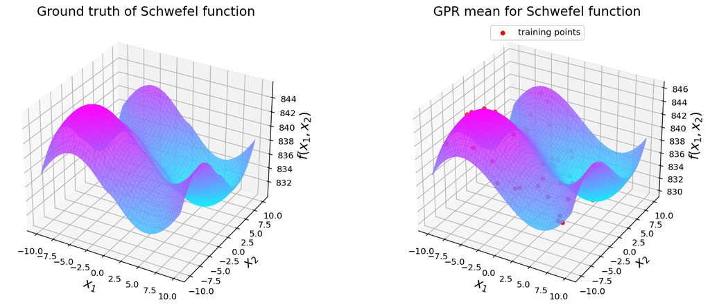

```python
fig3
```

We can also plot this information via contour plots, and show not only the mean predicted by GPR but also the standard deviation.

Note: you can also overlay the 95% confidence intervals in a surface plot, but usually it becomes really cluttered (so we didn't do it).

```python
fig4 = plt.figure(figsize=plt.figaspect(0.5)); ax4 = []
# Create Contour plot:
ax4.append(fig4.add_subplot(1, 3, 1))
cset = ax4[0].contourf(X1_grid, X2_grid, Y_grid, cmap=set_cm)
ax4[0].set_xlabel('$x_1$', fontsize=15)
ax4[0].set_ylabel('$x_2$', fontsize=15)
ax4[0].set_title("Ground truth of %s function" % function_name, fontsize=15)
fig4.colorbar(cset, ax=ax4[0])

# Create Contour plot:
ax4.append(fig4.add_subplot(1, 3, 2))
cset = ax4[1].contourf(X1_grid, X2_grid, Y_grid_data_GPpred, cmap=set_cm)
ax4[1].set_xlabel('$x_1$', fontsize=15)
ax4[1].set_ylabel('$x_2$', fontsize=15)
ax4[1].set_title("GPR mean for %s function" % function_name, fontsize=15)
fig4.colorbar(cset, ax=ax4[1])

# Create Contour plot:
ax4.append(fig4.add_subplot(1, 3, 3))

SIGMA_grid_data_GPpred = np.reshape(sigma_data_GPpred,np.shape(X1_grid))

cset = ax4[2].contourf(X1_grid, X2_grid, SIGMA_grid_data_GPpred, cmap=set_cm)
ax4[2].set_xlabel('$x_1$', fontsize=15)
ax4[2].set_ylabel('$x_2$', fontsize=15)
ax4[2].set_title("GPR STDV for %s function" % function_name, fontsize=15)
fig4.colorbar(cset, ax=ax4[2])

plt.tight_layout()
fig4.set_size_inches(15, 6)
plt.close(fig4) # close figure to open it in next cell.
```

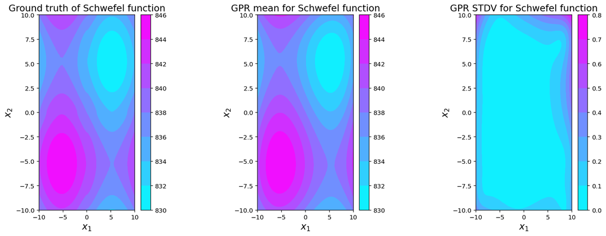

```python
fig4 # show same results but using contour plots.
```

It's quite remarkable that GPR predicts this function almost perfectly while using only 50 points! This is equivalent to using just $\sqrt{50}\approx 7$ points per dimension!

Let's now compute the $R^2$ error metric for the GPR approximation.

```python
from sklearn.metrics import r2_score # Import error metrics

# Compute MSE and R2 for the GP model
gp_r2_value = r2_score(y_test, y_test_GPpred)

print('R2 score for GPR = ', gp_r2_value)
```

```
R2 score for GPR =  0.995660118433014
```

#### An important issue in Gaussian processes: lack of scalability

- Redo the GP regression of the Schwefel function but now using 75% of the data for training.

Unfortunately, it is not uncommon for a Machine Learning problem to have millions of data points... But GPs cannot deal with this because the computational cost scales cubically with the number of datapoints: $\mathcal{O}(n^3)$.

The reason for this issue comes from the need to invert the covariance matrix, which is a $n\times n$ matrix where $n$ is the number of training points.

- **To keep in mind**: Gaussian processes are very powerful for small datasets, but they do not scale well for large datasets.

# HOMEWORK

Redo the Gaussian Processes Regression (GPR) of the Schwefel function for these conditions:

1. Training for data where you only scale the **inputs** using the StandardScaler. You get the same warning message (convergence difficulties to find the parameters of the kernel). **Why?**
2. Training for data where you only scale the **outputs** before training. This time your predictions are as good as the ones obtained when scaling both the inputs and the outputs. **Why?**
3. Create your own StandardScaler class achieving the same as scikit-learn's StandardScaler, but where the inverse_transform for the standard deviation does not need to be corrected like we did in the Lecture.

### You will explore these and other things in the Midterm Project...

Have fun!